# Air Transport Since 2023, Winners & Losers

## Part 2: Observing Delay Trends at Winning & Losing Airports

We pulled on-time service data using R’s Skynet package for March 2013, 2015, 2017, 2019, 2021, and 2023 to observe changes over time in on-time service for our selected airports. We calculated the mean, standard deviation, and median departure and arrival delays for all four airports, as well as the standard deviation. Since the data is discrete and distributed abnormally, we decided to compare median departure and arrival delays per airport per year to see if we observed meaningful changes over the study period.

```r
#skynet pull

ontime_2023_3 <- download_ontime(y = 2023, m = 3, auto = TRUE)
ontime_2021_3 <- download_ontime(y = 2021, m = 3, auto = TRUE)
ontime_2019_3 <- download_ontime(y = 2019, m = 3, auto = TRUE)
ontime_2017_3 <- download_ontime(y = 2017, m = 3, auto = TRUE)
ontime_2015_3 <- download_ontime(y = 2015, m = 3, auto = TRUE)
ontime_2013_3 <- download_ontime(y = 2013, m = 3, auto = TRUE)

# filtering for airports of interest

ontime_2023_3_org <- ontime_2023_3 %>%
  filter(origin %in% c("MCO", "PHL", "SAV", "DAY")) %>%
  select(origin, year, dep_delay) %>%
  rename(delay = dep_delay) %>%
  mutate(direction = "Departure")

ontime_2023_3_dest <- ontime_2023_3 %>%
  filter(dest %in% c("MCO", "PHL", "SAV", "DAY")) %>%
  select(dest, year, arr_delay) %>%
  rename(delay = arr_delay) %>%
  mutate(direction = "Arrival")

ontime_2021_3_org <- ontime_2021_3 %>%
  filter(origin %in% c("MCO", "PHL", "SAV", "DAY")) %>%
  select(origin, year, dep_delay) %>%
  rename(delay = dep_delay) %>%
  mutate(direction = "Departure")

ontime_2021_3_dest <- ontime_2021_3 %>%
  filter(dest %in% c("MCO", "PHL", "SAV", "DAY")) %>%
  select(dest, year, arr_delay) %>%
  rename(delay = arr_delay) %>%
  mutate(direction = "Arrival")

ontime_2019_3_org <- ontime_2019_3 %>%
  filter(origin %in% c("MCO", "PHL", "SAV", "DAY")) %>%
  select(origin, year, dep_delay) %>%
  rename(delay = dep_delay) %>%
  mutate(direction = "Departure")

ontime_2019_3_dest <- ontime_2019_3 %>%
  filter(dest %in% c("MCO", "PHL", "SAV", "DAY")) %>%
  select(dest, year, arr_delay) %>%
  rename(delay = arr_delay) %>%
  mutate(direction = "Arrival")

ontime_2017_3_org <- ontime_2017_3 %>%
  filter(origin %in% c("MCO", "PHL", "SAV", "DAY")) %>%
  select(origin, year, dep_delay) %>%
  rename(delay = dep_delay) %>%
  mutate(direction = "Departure")

ontime_2017_3_dest <- ontime_2017_3 %>%
  filter(dest %in% c("MCO", "PHL", "SAV", "DAY")) %>%
  select(dest, year, arr_delay) %>%
  rename(delay = arr_delay) %>%
  mutate(direction = "Arrival")

ontime_2015_3_org <- ontime_2015_3 %>%
  filter(origin %in% c("MCO", "PHL", "SAV", "DAY")) %>%
  select(origin, year, dep_delay) %>%
  rename(delay = dep_delay) %>%
  mutate(direction = "Departure")

ontime_2015_3_dest <- ontime_2015_3 %>%
  filter(dest %in% c("MCO", "PHL", "SAV", "DAY")) %>%
  select(dest, year, arr_delay) %>%
  rename(delay = arr_delay) %>%
  mutate(direction = "Arrival")

ontime_2013_3_org <- ontime_2013_3 %>%
  filter(origin %in% c("MCO", "PHL", "SAV", "DAY")) %>%
  select(origin, year, dep_delay) %>%
  rename(delay = dep_delay) %>%
  mutate(direction = "Departure")

ontime_2013_3_dest <- ontime_2013_3 %>%
  filter(dest %in% c("MCO", "PHL", "SAV", "DAY")) %>%
  select(dest, year, arr_delay) %>%
  rename(delay = arr_delay) %>%
  mutate(direction = "Arrival")

#bind, group_by, and summarize for viz

arr_delay_rbind <- rbind(ontime_2023_3_dest, ontime_2021_3_dest,
                         ontime_2019_3_dest, ontime_2017_3_dest,
                         ontime_2015_3_dest, ontime_2013_3_dest) %>%
  na.omit() %>%
  rename(flight_year = year)

arr_delay_sum <- arr_delay_rbind %>%
  group_by(dest, flight_year) %>%
  summarize(med_arr_delay = median(delay, na.rm = TRUE),
            avg_arr_delay = mean(delay, na.rm = TRUE),
            sd_delay = sd(delay, na.rm = TRUE))

dept_delay_rbind <- rbind(ontime_2023_3_org, ontime_2021_3_org,
                         ontime_2019_3_org, ontime_2017_3_org,
                         ontime_2015_3_org, ontime_2013_3_org) %>%
  na.omit() %>%
  rename(flight_year = year)

dept_delay_sum <- dept_delay_rbind %>%
  group_by(origin, flight_year) %>%
  summarize(med_dept_delay = median(delay, na.rm = TRUE),
            avg_dept_delay = mean(delay, na.rm = TRUE),
            sd_delay = sd(delay, na.rm = TRUE))
```

Dayton and Philadelphia observed median delays that got more negative over time, perhaps indicating that the airport has plenty of room for aircraft and reduced runway demand, allowing aircraft to land or depart comparatively quickly. This tracks given the significant reduction in annual enplanements observed. There is reason to believe that Philadelphia- and Dayton-area travelers are either choosing other modes or flying out of different airports, and reason to believe that visitors to these destinations are both decreasing in quantity and possibly choosing other nearby airports to access lower fares or better services.

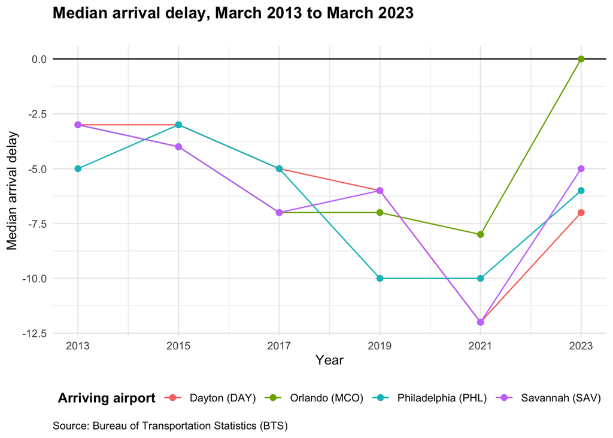

```r
ggplot(arr_delay_sum,
       aes(x = flight_year, y = med_arr_delay, color = dest)) +
  geom_line() +
  geom_hline(yintercept = 0) +
  scale_color_discrete(name = "Arriving airport",
                       labels = c("Dayton (DAY)", "Orlando (MCO)",
                                  "Philadelphia (PHL)", "Savannah (SAV)")) +
  scale_x_continuous(breaks = c(2013, 2015, 2017, 2019, 2021, 2023),
                     labels = c("2013", "2015", "2017", "2019", "2021", "2023")) +
  geom_point(size = 2) +
  theme_minimal() +
  labs(title = "Median arrival delay, March 2013 to March 2023",
       x = "Year",
       y = "Median arrival delay",
       caption = "Source: Bureau of Transportation Statistics (BTS)") +
  theme(legend.position = "bottom",
        plot.title = element_text(face = "bold", margin = margin(b = 20)),
        legend.title = element_text(face = "bold"),
        plot.caption = element_text(hjust = 0))
```

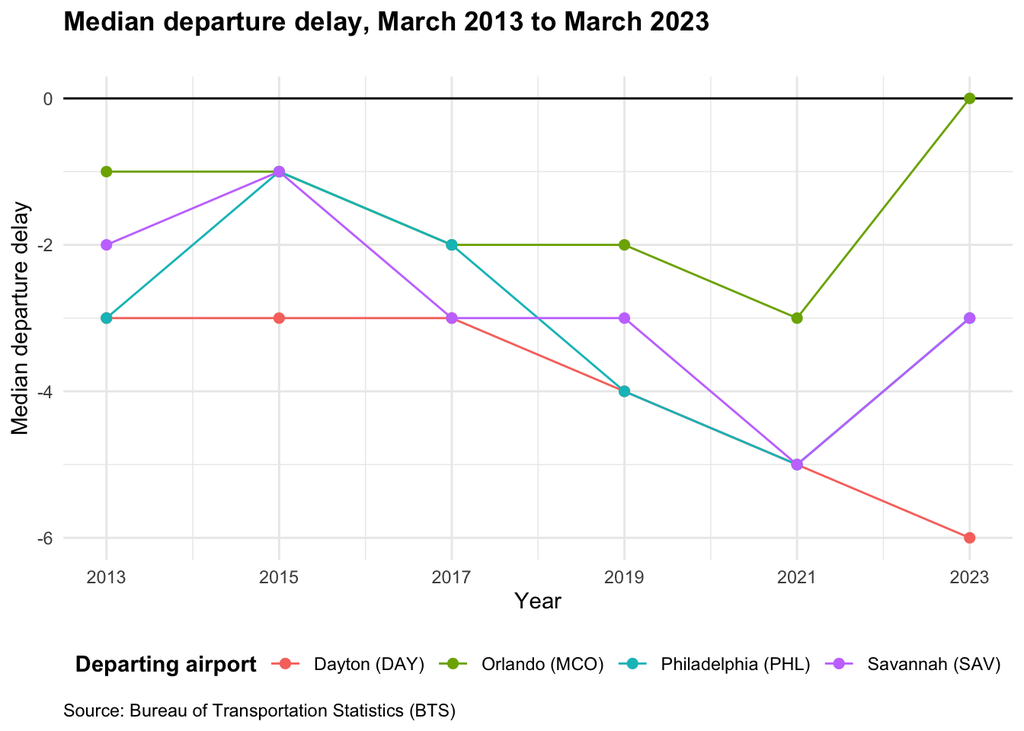

```r
ggplot(dept_delay_sum,
       aes(x = flight_year, y = med_dept_delay, color = origin)) +
  geom_line() +
  geom_hline(yintercept = 0) +
  scale_color_discrete(name = "Departing airport",
                       labels = c("Dayton (DAY)", "Orlando (MCO)",
                                  "Philadelphia (PHL)", "Savannah (SAV)")) +
  scale_x_continuous(breaks = c(2013, 2015, 2017, 2019, 2021, 2023),
                     labels = c("2013", "2015", "2017", "2019", "2021", "2023")) +
  geom_point(size = 2) +
  theme_minimal() +
  labs(title = "Median departure delay, March 2013 to March 2023",
       x = "Year",
       y = "Median departure delay",
       caption = "Source: Bureau of Transportation Statistics (BTS)") +
  theme(legend.position = "bottom",
        plot.title = element_text(face = "bold", margin = margin(b = 20)),
        legend.title = element_text(face = "bold"),
        plot.caption = element_text(hjust = 0))
```